# Computational results (preliminary version)

This report is a preliminary version of the computational results included in the paper

Nicolas Forget http://pure.au.dk/portal/en/nforget@econ.au.dk (CORAL, BSS, Aarhus University)https://econ.au.dk/coral , Lars Relund Nielsen http://pure.au.dk/portal/en/larsrn@econ.au.dk (CORAL, BSS, Aarhus University)https://econ.au.dk/coral , Sune Lauth Gadegaard http://pure.au.dk/portal/en/sgadegaard@econ.au.dk (CORAL, BSS, Aarhus University)https://econ.au.dk/coral  
2021-06-16

*This report is a preliminary version of the computational results included in the paper. Only instances generated with option spheredown are used since they seems to be hard instances.*

In this section we report on the computational experiments conducted with the tri–objective branch–and–bound algorithm.

All instances are converted to minimization problems meaning that if an objective function $z(x)$ should be maximized, $−z(x)$ is minimized instead.

The purpose of the computational study is to answer the following questions:

1. What is the performance of the different algorithm configurations and which configurations perform the best? In particular, is it worth doing objective branching?
2. Why does objective branching perform as it does?
3. Which node selection strategy performs best?
4. How is the performance of the tri-objective B&B algorithm compared to an objective space search algorithm?

# Impelmentation details and algorithm configurations

All algorithms were implemented in Julia $1.0.1$. The experiments was carried out on a computer with an Intel(R) Core(TM) i7-4785T CPU @ 2.20GHz processor and 16GB of RAM memory, using Linux Ubuntu 14.04 LTS.

In order to compute the linear relaxation at each node, the solver [Bensolve](https://www.optimierung-loehne.uni-jena.de/bensolve) is used (Lohne and Weibing, n.d.). To avoid reading and writing text files at each node of the tree, we have implemented a wrapper that calls Bensolve, retrieves some outputs and inserts them directly in our code as matrices. Numerical instabilities occured during the computation of lower bound sets, leading to missing non-dominated points in the final output. The matrix used when finding the normal to each hyperplane of a lower bound set may in a few cases be close to singular (its determinant is close to zero). Hence a small value $\epsilon$ has been introduced so that if the determinant is less than or equal $\epsilon$, then the hyperplane is discarded, thus leaving a weaker but valid lower bound set. For more information, we refer the reader to the [section about numerical instabilities](https://mcdmsociety.github.io/MOrepo-Forget20/report.html#numerical-instablities) in Forget, Nielsen, and Gadegaard (2020a). We used $\epsilon = 0.001$ in all tests reported in this paper resulting in no missing non-dominated points.

The branching variable selected in Step 5 of Algorithm~1 differs depending on whether objective branching is applied or not. If no objective branching is performed, the algorithm will branch on the free variable that is the most often fractional among the extreme points of the lower bound set, given that at least one of the variables takes fractional value. If no variable takes a fractional value in any of the extreme points, the variable that is the most often different (i.e. with the average value closest to $0.5$) is chosen. If objective branching is enabled, the rule is the same, except that a different variable may be chosen in each sub-problem. In case objective branching is applied on $s \in \mathbb{R}^p$, only the extreme points of the lower bound set included in $\mathcal{C}(s)$ will be considered. If multiple choices are possible or no extreme point is located in $\mathcal{C}(s)$, the variable with the smallest index is chosen.

To test different algorithm configurations we use the following parameters:

- Two node selection methods are considered (Step 1 of Algorithm 1):
  - `B`: breadth first strategy.
  - `D`: depth first strategy.
- Three objective branching strategies are considered:
  - `N`: no objective branching is performed. This is the equivalent of skipping Step 4 of Algorithm 1.
  - `F`: full objective branching using super local upper bounds (see Algorithm 2).
  - `C`: objective branching using a single cone, namely, the nadir point of the local upper bounds dominated by the lower bound set (see Section 4.3).

This leads to 6 configurations: `B|N`, `B|F`, `B|C`, `D|N`, `D|F` and `D|C`. For an overview of more configurations such as different variable selection rules (Step 5 of the algorithm), the reader is referred to Forget, Nielsen, and Gadegaard (2020a).

For the comparison with an OSS algorithm, the approach proposed in Tamby (2018) was implemented, as the authors show that their method performs better than other OSS algorithms from the literature, particularly on knapsack and assignment problems (see next section). A short description of the algorithm is given in the appendix. As the LP solver in Bensolve is GLPK, the same MIP solver was used for the OSS. Due to technical constraints in the chosen programming language (Julia), the MIP solver could not be warm started. Warm starting the MIP solver would lead to improved cpu times. However, note that the same holds for the branch and bound algorithm which also does not use warm starting when calculating the lower bound set in each node of the branching tree, since this is not possible using Bensolve.

All algorithms and configurations have been tested using a time limit of half an hour (1800 seconds).

# Test instances

Table 1: Instances used.

|  | $n$<sup>a</sup> | #<sup>b</sup> |
| --- | --- | --- |
| AP | 36, 49, 64, 121 | 10 |
| KP | 10, 15, 20, 25, 30, 35, 40 | 30 |
| UFLP | 30, 42, 56, 72 | 10 |

<sup>a</sup> Number of variables.  
<sup>b</sup> Number of instances for each variable size

The objective coefficients are generated in the range [1, 1000] on the lower part of a 3D sphere using the R package Relund Nielsen (2020). Hence a large number of the coefficient vectors for the variables are non-dominated among each other (91% for the AP and 96% for the KP). This way of generating the objective coefficients was tested against other methods and seems to result in solutions with a large number of non-dominated points (Forget, Nielsen, and Gadegaard 2020a) (implying hard instances). For the UFLP instances the same generation method has been used. However, since two cost groups exists (see the appendix), a range of [1, 1000] was used for generating the cost of assigning a customer to a service point and a range of [1, 100] for generating the cost for opening a service point. The objective coefficients are all integer.

For the AP the constraints are fixed given the problem size. The same holds for the UFLP when assuming the number of facilities equals the number of customers. For the KP instances however, the integer coefficients of the constraint are generated randomly in the range [1,15]. The right-hand side is set equal to half of the sum of the coefficients on the right hand side, rounded down. For the KP, three different constraints are generated for each variable size and objective coefficients.

All instances are publicly available at Multi-Objective Optimization Repository (MOrepo) (Nielsen 2017) in a sub-repository (Forget, Nielsen, and Gadegaard 2020c). Moreover the repository also contains further instances used for preliminary testing (only the hardest instances are kept in this paper). An overview of all the results is given in (Forget, Nielsen, and Gadegaard 2020a). The non-dominated sets for each instance are available together with detailed results and plots of some of the instances Forget, Nielsen, and Gadegaard (2020b).

# Performance of the different algorithm configurations

First, we rank the configurations with respect to mean cpu time for all instances. The sequence from best to worst becomes B|C (0%), D|C (15%), B|N (16%), D|N (33%), B|F (50%), D|F (78%) where the increase in percent compared to the best configuration is given in parentheses. Note that the mean cpu times calculated are in fact a lower bound due to the total run time limit.

Second, a comparison of the different algorithm configurations for given problem class can be seen in Figure 1. Note that we have increased the variable size for each problem class until the size becomes large enough that some instances cannot be solved within the time limit. That is, the number of instances solved before the time limit is obviously under 100%.

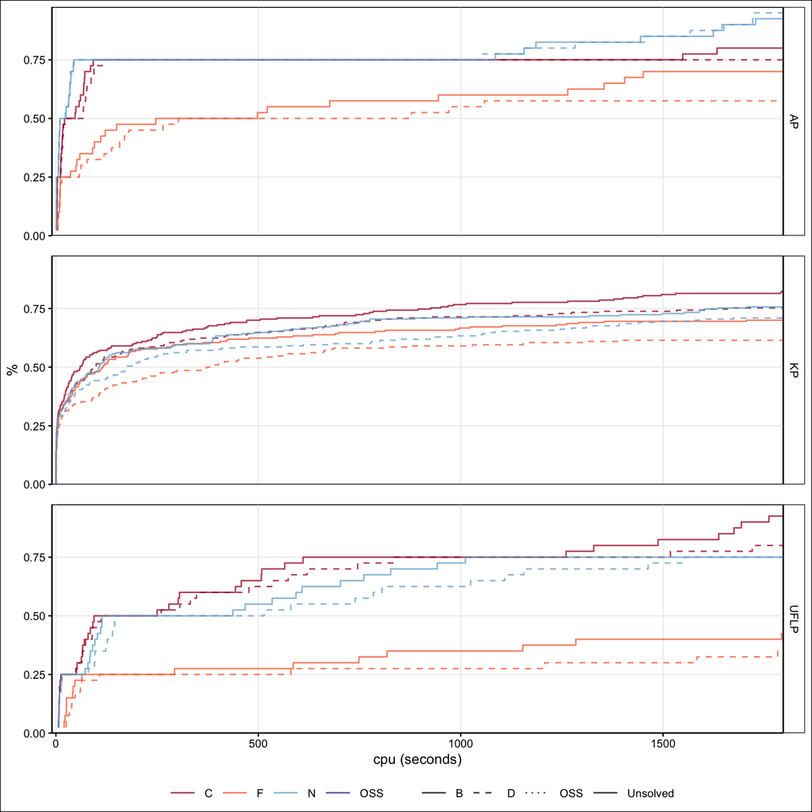

Figure 1: Performance profile: Number of instances in percent solved given cpu time. An instance is considered as unsolved if the cpu time exceed 1800 seconds (time limit).

From Figure 1, the reader should note the following general observations:

- In general, full objective branching (`B|F` and `D|F`) performs poorly compared to the other configurations. This is especially evident for the AP and the UFLP. For the KP, using full objective branching is still among the worst performing strategies.
- For both the KP and the UFLP, the best objective branching configuration is using a single cone (`C`), while not using objective branching (`N`) performs best for the AP.
- In general node selection using breadth first strategies tend to perform better than depth first strategies given the objective branching strategy.

These observations will be elaborated upon in the next sections.

Finally, consider the winning algorithm configurations in Figure 2. Note that for the KP and the UFLP using no objective branching is competitive for some of the smaller instances. Furthermore, in general there is no configuration that consistently wins. That is, algorithms using different node selection and objective branching strategies during the solution procedure may be useful.

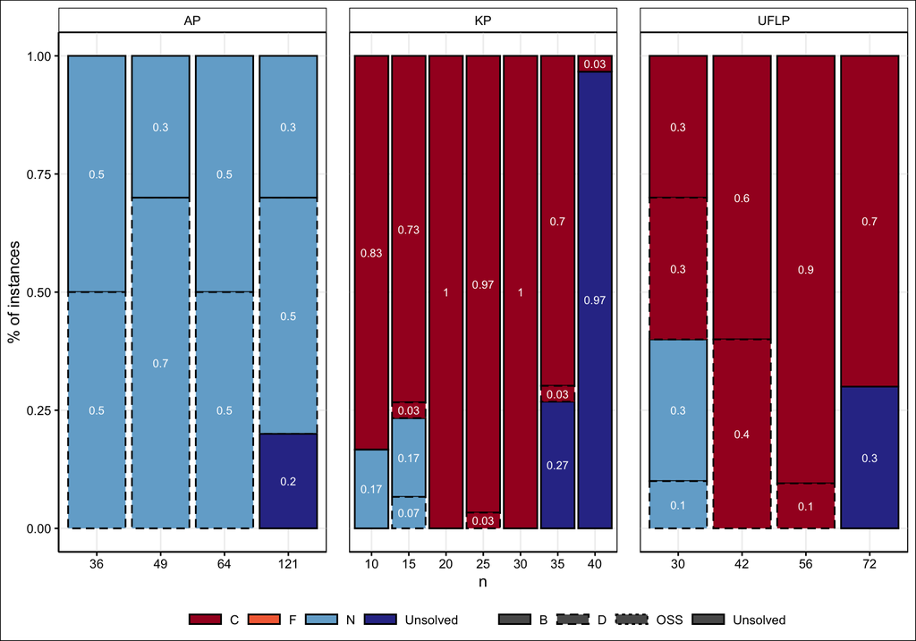

Figure 2: Proportion of winning algorithm configurations.

# Objective branching: a closer look

For taking a closer look at the different objective branching configurations we limit the analysis to the set of instances which was solved to optimality for all algorithm configurations. Detailed summary statistics are given in Table 2.

Table 2: Detailed results for all instances which have been solved to optimality for all algorithm configurtions. The winner among the configurations for a column has been highlighted in bold. Summary statistics for each problem class is given in a grey row.

| n<sup>a</sup> | #<sup>b</sup> | \|YN\|<sup>c</sup> | B\|C cpu<sup>d</sup> | B\|C cpuLB<sup>e</sup> | B\|C nodes<sup>f</sup> | B\|C prune<sup>g</sup> | B\|F cpu<sup>d</sup> | B\|F cpuLB<sup>e</sup> | B\|F nodes<sup>f</sup> | B\|F prune<sup>g</sup> | B\|N cpu<sup>d</sup> | B\|N cpuLB<sup>e</sup> | B\|N nodes<sup>f</sup> | B\|N prune<sup>g</sup> | D\|C cpu<sup>d</sup> | D\|C cpuLB<sup>e</sup> | D\|C nodes<sup>f</sup> | D\|C prune<sup>g</sup> | D\|F cpu<sup>d</sup> | D\|F cpuLB<sup>e</sup> | D\|F nodes<sup>f</sup> | D\|F prune<sup>g</sup> | D\|N cpu<sup>d</sup> | D\|N cpuLB<sup>e</sup> | D\|N nodes<sup>f</sup> | D\|N prune<sup>g</sup> |
| --- | --- | --- | --- | --- | --- | --- | --- | --- | --- | --- | --- | --- | --- | --- | --- | --- | --- | --- | --- | --- | --- | --- | --- | --- | --- | --- |
| **AP** |  |  |  |  |  |  |  |  |  |  |  |  |  |  |  |  |  |  |  |  |  |  |  |  |  |  |
| 36 | 10 | 160 (14/0/86) | 2.8 [1.9,3.5] | 2.3 | 1540 [3,18,27] | [83,11,6] | 7.8 [3.5,11.2] | 2.7 | 2594 [3,17,26] | [91,5,4] | 1.4 [1.1,1.7] | 1.5 | 807 [6,11,16] | [0,74,26] | 3 [2.1,3.7] | 2.2 | 1783 [3,19,27] | [83,12,5] | 8.4 [3.5,14.7] | 2.7 | 2640 [3,18,27] | [91,7,2] | 1.4 [1.1,1.6] | 1.5 | 831 [6,11,16] | [0,76,24] |
| 49 | 10 | 348 (8/0/92) | 14.9 [11.4,21.4] | 3.3 | 4933 [3,25,38] | [82,8,11] | 101.2 [35.9,246.8] | 3.6 | 11225 [3,21,37] | [92,3,5] | 7.8 [6,10] | 2.4 | 2573 [7,13,20] | [0,59,41] | 16.1 [12.3,23.4] | 3.2 | 6170 [3,26,38] | [83,9,8] | 152.7 [58.1,302.7] | 3.6 | 12037 [3,22,38] | [94,3,2] | 7.6 [6,9.8] | 2.3 | 2847 [7,13,21] | [0,62,38] |
| 64 | 3 | 587 (7/0/93) | 51.4 [47.5,57.5] | 4.7 | 11489 [3,29,51] | [78,6,16] | 565.5 [498,676.2] | 4.4 | 34192 [3,24,50] | [92,1,7] | 28.4 [24.8,35] | 3.6 | 6182 [8,15,27] | [0,46,54] | 72.5 [68,76.8] | 4.5 | 19421 [3,32,52] | [82,7,11] | 969.3 [878.6,1058.7] | 4.7 | 44736 [3,27,51] | [95,2,3] | 28.2 [23.4,35.4] | 3.4 | 7166 [8,15,27] | [0,50,50] |
|  | 23 | 298 (9/0/91) | 14.4 [1.9,57.5] | 3.1 | 4313 [3,23,35] | [82,9,9] | 121.1 [3.5,676.2] | 3.3 | 10468 [3,20,34] | [92,4,5] | 7.7 [1.1,35] | 2.2 | 2276 [7,12,19] | [0,64,36] | 17.8 [2.1,76.8] | 2.9 | 5991 [3,24,35] | [83,10,7] | 196.5 [3.5,1058.7] | 3.3 | 12216 [3,21,35] | [93,5,2] | 7.6 [1.1,35.4] | 2.1 | 2534 [7,12,20] | [0,66,34] |
| **KP** |  |  |  |  |  |  |  |  |  |  |  |  |  |  |  |  |  |  |  |  |  |  |  |  |  |  |
| 10 | 30 | 43 (28/0/72) | 0.2 [0.1,0.3] | 0.7 | 315 [5,9,11] | [63,28,8] | 0.2 [0.1,0.4] | 0.9 | 350 [5,9,11] | [71,22,6] | 0.2 [0.1,0.3] | 0.6 | 336 [5,9,11] | [28,46,26] | 0.2 [0.1,0.4] | 0.7 | 371 [5,9,11] | [64,32,4] | 0.3 [0.1,0.7] | 0.8 | 404 [5,9,11] | [71,26,3] | 0.2 [0.1,0.3] | 0.6 | 393 [5,9,11] | [33,49,18] |
| 15 | 30 | 145 (16/0/84) | 2.4 [0.9,5.5] | 1.1 | 2238 [7,12,16] | [67,19,14] | 3.7 [1.3,9.2] | 1.4 | 2951 [6,11,16] | [79,12,10] | 2.9 [1.3,5] | 1.1 | 2499 [7,13,16] | [12,43,45] | 3.2 [1.5,7.1] | 1 | 3117 [7,13,16] | [70,21,9] | 6.7 [2,19] | 1.3 | 3910 [6,12,16] | [81,14,5] | 3.4 [1.9,5.7] | 1 | 3540 [7,13,16] | [19,46,35] |
| 20 | 30 | 329 (10/0/90) | 18.2 [2.5,43.8] | 1.5 | 10335 [7,16,21] | [72,12,16] | 35.6 [3.3,147.2] | 1.9 | 16899 [6,14,21] | [84,6,11] | 26.4 [5,50.6] | 1.8 | 12484 [7,16,21] | [9,43,49] | 28.5 [3.2,71.8] | 1.4 | 18618 [7,16,21] | [75,14,11] | 103.5 [4.4,413.6] | 1.8 | 27738 [6,15,21] | [88,7,5] | 39.3 [6.7,83.6] | 1.5 | 23616 [7,17,21] | [14,43,43] |
| 25 | 29 | 550 (8/0/92) | 58.1 [23.5,107.6] | 2.1 | 22251 [7,18,26] | [70,9,20] | 111.2 [38.1,218.9] | 2.5 | 39468 [6,16,26] | [84,4,12] | 102.1 [46.4,184.8] | 3 | 27918 [7,19,26] | [3,41,56] | 98.8 [41.6,184.5] | 1.8 | 50927 [8,19,26] | [75,10,15] | 366.2 [89,867.4] | 2.3 | 81458 [6,17,26] | [90,5,6] | 182.2 [82.2,323.8] | 2.4 | 68127 [7,20,26] | [6,44,50] |
| 30 | 10 | 752 (7/0/93) | 182.2 [101.6,250.9] | 3 | 42622 [8,20,31] | [71,7,22] | 302.9 [127.2,424.3] | 3.3 | 76974 [6,17,31] | [85,3,12] | 317.7 [196.3,395] | 5 | 53069 [8,21,31] | [2,47,52] | 247.4 [147,325.3] | 2.4 | 102150 [8,21,31] | [76,9,15] | 896.6 [185.9,1401.7] | 2.8 | 164866 [5,19,31] | [90,4,6] | 621.1 [323.1,837.5] | 4 | 138892 [7,23,31] | [4,48,48] |
|  | 129 | 302 (10/0/90) | 32 [0.1,250.9] | 1.5 | 11303 [7,14,19] | [68,17,15] | 57.7 [0.1,424.3] | 1.8 | 19537 [6,13,19] | [80,10,10] | 54.4 [0.1,395] | 1.9 | 13953 [7,15,19] | [12,44,44] | 48.8 [0.1,325.3] | 1.3 | 24508 [7,15,19] | [71,19,10] | 177.5 [0.1,1401.7] | 1.6 | 38546 [6,14,19] | [83,12,5] | 99.1 [0.1,837.5] | 1.6 | 32489 [7,15,19] | [17,46,37] |
| **UFLP** |  |  |  |  |  |  |  |  |  |  |  |  |  |  |  |  |  |  |  |  |  |  |  |  |  |  |
| 30 | 10 | 325 (14/0/86) | 8.4 [6.2,12.4] | 2.7 | 3157 [3,19,26] | [75,16,9] | 33.4 [18.3,64.1] | 3.3 | 6158 [3,17,26] | [89,6,5] | 9.4 [5.9,14.5] | 2.1 | 3517 [7,14,21] | [0,65,35] | 8.9 [6.1,12.3] | 2.6 | 3868 [3,20,26] | [75,18,7] | 47.2 [25.3,108] | 3.1 | 6758 [3,17,26] | [90,8,3] | 9.4 [6.8,15.3] | 1.9 | 4270 [7,14,22] | [0,70,30] |
| 42 | 4 | 900 (8/0/92) | 59 [50.7,70.3] | 4.1 | 13026 [4,25,39] | [76,10,14] | 712.8 [293.1,1153.5] | 4.1 | 34729 [4,21,38] | [91,3,6] | 90.4 [72.1,113.8] | 4.1 | 16508 [8,17,32] | [0,50,50] | 61.1 [48.9,73.2] | 3.8 | 17300 [4,25,39] | [77,12,10] | 1288.7 [580.4,1783.3] | 4.1 | 39028 [4,22,39] | [93,4,3] | 110 [80.3,139.7] | 3.6 | 25250 [8,18,32] | [0,55,45] |
|  | 14 | 489 (11/0/89) | 22.9 [6.2,70.3] | 3.1 | 5977 [4,21,30] | [75,14,10] | 227.5 [18.3,1153.5] | 3.5 | 14321 [4,18,30] | [90,5,5] | 32.5 [5.9,113.8] | 2.7 | 7229 [7,15,24] | [0,61,39] | 23.8 [6.1,73.2] | 3 | 7705 [4,21,30] | [76,17,8] | 401.9 [25.3,1783.3] | 3.4 | 15978 [4,19,30] | [91,7,3] | 38.1 [6.8,139.7] | 2.4 | 10264 [7,15,25] | [0,66,34] |

<sup>a</sup> Number of variables.  
<sup>b</sup> Number of instances.  
<sup>c</sup> Avg. number of non-dominated points (supported extreme, supported non-extreme and unsupported in percent).  
<sup>d</sup> Avg. cpu time (seconds). Square brackets contains the range.  
<sup>e</sup> Avg. cpu time (miliseconds) used to find the LB set per node where LB set found.  
<sup>f</sup> Avg. number of nodes in the branching tree. Square brackets contains the min, avg. and max depth of leaf nodes.  
<sup>g</sup> Percentages of leaf nodes pruned by infisibility, optimality and dominance.

Figure 1 illustrates that using full objective branching (`F`) is not efficient with respect to cpu time. As explained in Section 4.3, full objective branching creates more nodes (in average 3.1) in the branch and bound tree as it partitions the objective space in smaller regions. This seems to lead to longer computation times, since computing the lower bound set of each node is computationally very expensive. Indeed, this can be seen in Figure 3 where `F` configurations produce more nodes in the search tree compared to `C` and `N` configurations given same node selection rule. This observation makes sense, as the purpose of objective branching as described in Algorithm 2 is to produce more sub-problems and thus get wider trees, in the expectation that these sub-problems will be easier to solve and that the tree will have a smaller depth. However, the branching nodes produced using full objective branching takes longer to process, on average. This can be seen in Table 2 if we compare the time used to find lower bound sets for configurations `F` and `C`. That is, the sub-problems generated in the `F` configurations tends to be harder to solve in average due to a more complicated set of constraints. Indeed, as the trees are wider using full objective branching, more nodes with fewer variables fixed to $0$ or $1$ (i.e. close to the root node) are generated. Unfortunately, localizing the branch and bound to smaller areas of the objective space using full objective branching doesn’t compensate the larger number of nodes with fewer fixed variables.

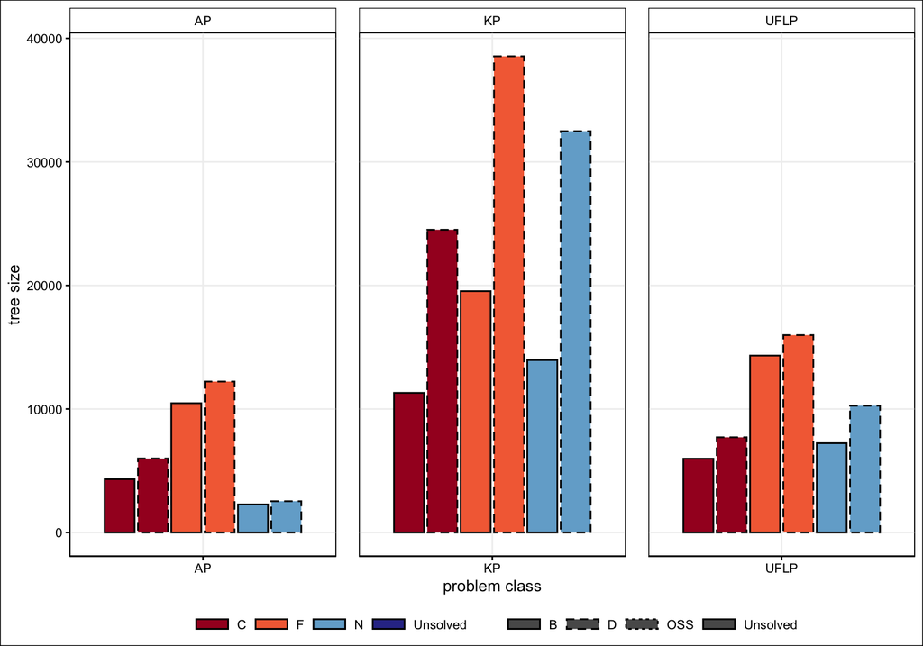

Figure 3: Average branching tree size.

To make full branching competitive the cpu time for calculating the lower bound set needs to be reduced. That is, computing the lower bound set faster than what is currently done using BenSolve. This would lead to large reductions in the overall computation time as most of the computational time is spent in computing the lower bound sets (approx. 66%). This would of course benefit to all the configurations, but in a greater proportion to `F` configurations, as they generate more nodes. Some ideas for reducing the cpu time could be to:

- implement a way to warm start the LP solver for each sub-problem,
- introduce an updating procedure of the lower bound set, instead of computing it from scratch at each node,
- use further pruning rules that discard sub-problems before calculating the lower bound set.

Updating and pruning procedures may include using the local information available in the subproblems with respect to the region in the objective space defined by a branching node. In Adelgren and Gupte (2019) it was shown that presolve techniques, contrary to the case of single-objective optimization, has a great effect deeper in the search tree. Hence, one could imagine that the solutions are more likely to be close in a specific part of the objective space and thus, by localizing the branch and bound, presolving the nodes or introducing cuts may have a significant impact.

Except for the AP, objective branching using a single cone (`C`) performs better than the `N` configurations in both cpu time and number of tree nodes. That is, objective branching is competitive. A first explanation of the efficiency of `C` configurations for the KP and the UFLP is that for a given node $\eta$, the `C` configurations will focus on a specific part of the objective space (a cone defined by $d^N(\eta)$) for the same number of sub-problems created (2, in the decision space). Thus, the lower bound sets tends to be less complex (some areas of the objective space are discarded before computation, while it is fully considered in the `N` version, and this, whithout generating additional nodes as in the `F` version), which means possibly spending less time in the most expensive part of the branch and bound (computing the lower bound sets). Second, the way nodes are fathomed is highly influenced by the choice of objective branching strategy. Indeed, as it can be seen in Table 2, in the `C` configurations, the proportion of nodes fathomed by infeasibility tends to be much higher than for the `N` configurations. This is due to the fact that additional constraints added in the `C` configurations will make sub-problems more likely to be infeasible. Moreover, fathoming a node by infeasibility is faster than fathoming a node by optimality or by dominance. To fathom by dominance or optimality, having the lower bound set computed is required. On the contrary, testing the feasibility of the sub-problem is the first thing done when a node is being explored.

The case of the AP is different from the KP and the UFLP. This is not surprising as the constraint matrix of the AP is totally unimodular implying the extreme points of the the polytope defined by the constraints are integral. Hence, all the extreme points of the lower bound sets correspond to feasible solutions in the `N` configurations. This implies that in Step 5, the branching rule will exploit this and thus, always branch on the most often different variable. On the contrary, as new constraints are added in the `C` configurations, the extreme points are not necessarily integer and the branching rule will choose to branch on the most often fractional variable. This difference in the branching rule may have a significant impact and thus, explain why for AP the `N` configurations are better.

# Node selection: breadth vs depth

In Figure 1, it was shown that the node selection using a breadth first strategy tends to perform better than a depth first strategy given an objective branching rule. This observation is in contrast to the prevalent use of depth first in multi-objective branch and bound algorithms (Przybylski and Gandibleux 2017).

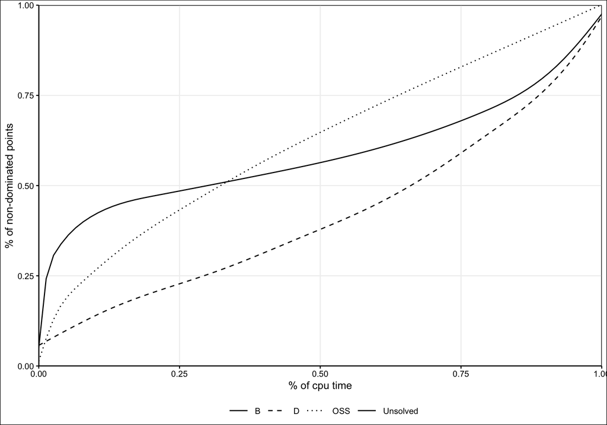

Figure 4: Smoothed curves of relative number of non-dominated points compared to relative cpu.

A possible explanation is that with a depth first strategy, the branch and bound algorithm tends to focus on specific parts of the objective space one by one. Using a breadth first strategy offers a better coverage of all the objective space earlier and thus, yields better upper bound sets earlier. This is confirmed if we take a look at Figure 4 where all the instances solved to optimality with no objective branching (`N`) or using a cone (`C`) have been grouped based on node selection strategy. Observe that using a breath first strategy (`B`) in general finds an approximation of the non-dominated set relatively faster, i.e. we obtain a better upper bound set. Since the figure reports relative numbers, it could be the case that a depth first strategy still is better if the cpu time is much better than a breath first strategy. However note that using a a breath first node selection strategy in general finds an optimal solution faster than a depth first node selection strategy (see Figure 1).

In addition, one can observe in Figure 4 that the curve that represent the number of non-dominated points found for breadth first strategies tends to grow very quickly in the begining and slowly flattens in the middle, to finally grow fast again towards the end. In the begining, the first layers of the tree are explored. As the problems in these layers are less constrained and the upper bound set is relatively sparsely populated, many new non-dominated points are found. When the branch and bound reaches deeper layers, towards the middle, the problems becomes more constrained, which generates less new non-dominated points. Towards the end, the deepest parts of the branch and bound tree are explored. The problems here are so constrained that they become much easier to solve (at most one feasible solution at layer `n` + 1, the deepest possible layer in the tree) and thus, are proceeded much faster. In addition to that, the solutions found deep in the tree are more likely to be integer and thus to generate new non-dominated points. This leads to the acceleration of the number of non-dominated points found near the end of the algorithm. This observation also suggests that it may be interesting to combine breadth and depth first strategies to reach quickly the parts of the tree that generate a lot of non-dominated points.

# Comparing the branch and bound algorithm with an objective space search algorithm

```
#> [1] 15.65446
#> [1] 3.759797
```

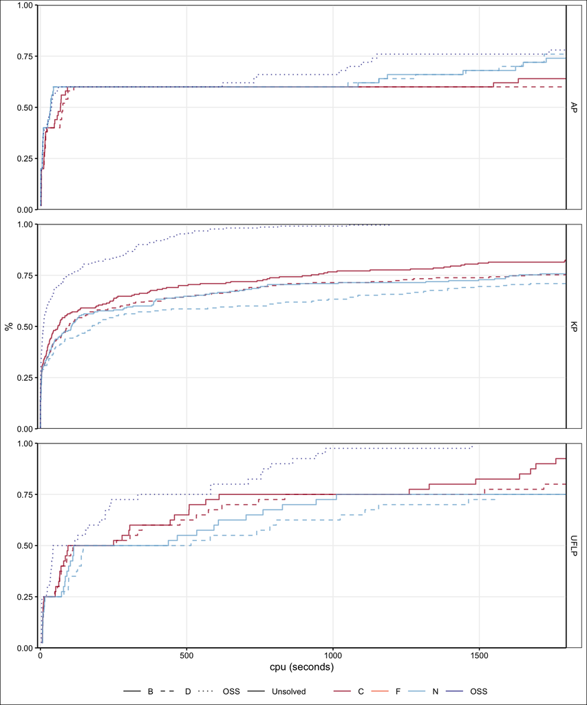

Figure 5: Performance profile: Number of instances in percent solved given cpu time. An instance is considered as unsolved if the cpu time exceed 1800 seconds (time limit).

It is to be expected that the OSS algorithm performs better since it benefits from the power of single-objective MIP solvers which has been improved over decades. The purpose of this paper is, to extend the concept of B&B from the bi-objective case to the tri-objective case and to investigate the behavior of such an algorithm. Thus, the scope is not to create an algorithm that outperforms all other algorithms for the tri-objective case. However, we do find it important to compare statistics from the branch and bound algorithm to statistics from the objective space search algorithm, as these are known to perform well on tri-objective combinatorial problems.

We believe that closing this gap is possible with further research in pruning nodes and finding lower bound sets faster (i.e. processing nodes faster) or by considering alternative node and variable selection rules (i.e. reducing the size of the tree and thus, decreasing this factor of 16). Also, the branch and bound algorithm uses no cut-generation which are heavily used by the single objective MIP solvers. Thus, generating cuts, and effectively extending the branch and bound to a branch and cut could lead to reduced tree sizes.

Furthermore, Figure 4 suggests that when the branch and bound approach becomes computationally competitive with the OSS approach, prematurely and early terminating the algorithm seems to lead to a better approximation of the pareto front for the B&B than for this OSS.

Adelgren, Nathan, and Akshay Gupte. 2019. “Branch-and-Bound for Biobjective Mixed-Integer Linear Programming.” http://www.optimization-online.org/DB_FILE/2016/10/5676.pdf.

Forget, N., L. R. Nielsen, and S. L Gadegaard. 2020a. “Computational Results (All Instances).” Aarhus University. https://mcdmsociety.github.io/MOrepo-Forget20/report.html.

Forget, N., L. R. Nielsen, and S. L. Gadegaard. 2020b. “Detailed Results for Instances (Morepo-Forget20).” 2020. https://mcdmsociety.github.io/MOrepo-Forget20/report_details.html.

———. 2020c. “Instances and Results for Tri-Objective Branch and Bound (Morepo-Forget20).” 2020. https://github.com/MCDMSociety/MOrepo-Forget20.

Lohne, A., and B. Weibing. n.d. “Bensolve.” http://www.bensolve.org/.

Nielsen, L. R. 2017. “Multi-Objective Optimization Repository (Morepo).” 2017. https://github.com/MCDMSociety/MOrepo.

Przybylski, A., and X. Gandibleux. 2017. “Multi-Objective Branch and Bound.” *European Journal of Operational Research* 260 (3): 856–72. https://doi.org/10.1016/j.ejor.2017.01.032.

Relund Nielsen, Lars. 2020. *GMOIP: Tools for 2D and 3D Plots of Single and Multi-Objective Linear/Integer Programming Models*. https://github.com/relund/gMOIP/.

Tamby, Satya. 2018. “Approches Génériques Pour La Résolution de Problèmes d’optimisation Discrète Multiobjectif.” PhD thesis, Université Paris-Dauphine.